# Homwwork6 STA578

Jiaming Chen

11/1/2017

## 1.a

iii: A model with higher degree of freedom has lower bias term but higher variance term. Lasso regression reduce the degree of freedom by adding a penalty term to the least square error regression. Thus a less flexible model (Lasso) is preferred if its decrease in variance is faster than its increase in in bias.

## 1.b

iii: Same as Lasso regression, Ridge regression is less flexible than least square error regression because of squared penalty term.

## 2.a

iv: When $s=0$ the linear coefficient $\boldsymbol{\beta}=0$, the model is fitting a constant ($df=0$) and the bias is the largest. As we increase $s$, we’re increasing the degree of freedom of the model as well, the model can fit the training data better. So the training RSS will decrease steadily.

## 2.b

ii: When the flexibility of the model increase as we increase $s$ from zero, the test RSS decrease initially as the bias term decrease and then increase as the variance increase because of overfitting.

## 2.c

iii: Variance steadily increase as the model flexibility increase. When $s$ increases $|\boldsymbol{\beta}|$ increase as well, the model become more flexible.

## 2.d

iv: Bias steadily decrease because when the model has a higher degree of freedom it can fit the training data better.

## 2.e

v: The irreducible error remains constant because it does not depend the model.

## 3.a

```r
data('College', package='ISLR')
set.seed(2112)
train = College %>% sample_frac(0.5)
test  = setdiff(College, train)
```

## 3.b

```r
LSE_model <- train( Apps ~ ., data=train, method='lm')
LSE_model$results
```

```
##   intercept     RMSE  Rsquared      MAE   RMSESD RsquaredSD    MAESD
## 1      TRUE 1476.436 0.8995933 846.0501 263.9626 0.01919659 86.73388
```

```r
test$yhat.LSE <- predict(LSE_model, newdata=test)
test %>% mutate(resid.LSE = Apps-yhat.LSE) %>%
  summarise( test.RMSE = sqrt(mean( resid.LSE^2 )))
```

```
##   test.RMSE
## 1  878.7222
```

## 3.c

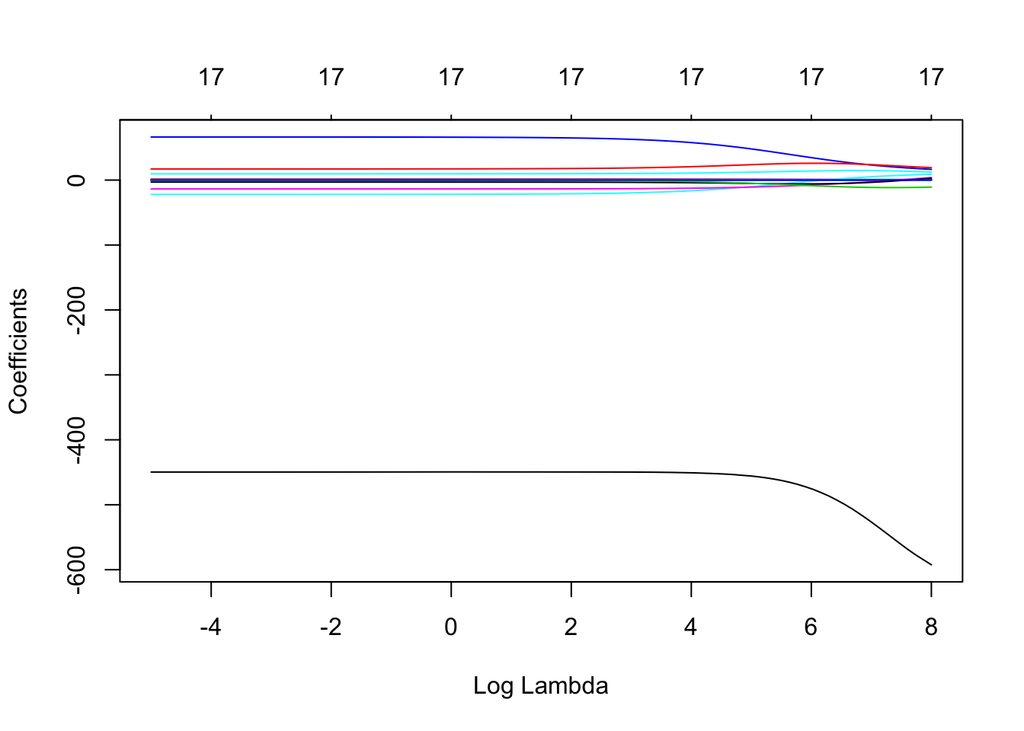

```r
# Define how we will do our cross validation to select the tuning parameter
ctrl <- trainControl( method='repeatedcv', repeats=4, number=5,
                      preProcOptions = c('center','scale'))  # center and scale the covariates first!
num = 20    # We did 20 hold out sets (4x5 fold CV)
# Define the grid of tuning parameters we will consider
grid <- data.frame(
  alpha  = 0,  # 0 => Ridge Regression
  lambda = exp(seq(-5, 8, length=100)) )  # Figured out this range via trial and error

ridge_model <- train( Apps ~ ., data=train, method='glmnet',
                trControl=ctrl, tuneGrid=grid,
                lambda= grid$lambda )   # Not sure why lambda isn't being passed in...

plot.glmnet(ridge_model$finalModel, xvar='lambda')
```

```r
# Best tuning value
ridge_model$bestTune
```

```
##    alpha    lambda
## 24     0 0.1380971
```

```r
best.index <- which.min( ridge_model$results[, 'RMSE'] )
# test error for best model
# I had problem using  predict(ridge_model$finalModel, newdata=test)
ridge_model.best <- train( Apps ~ ., data=train, method='glmnet',
                trControl=ctrl, tuneGrid=ridge_model$bestTune,
                lambda= ridge_model$bestTune )
ridge_model.best$results
```

```
##   alpha    lambda     RMSE Rsquared      MAE   RMSESD RsquaredSD    MAESD
## 1     0 0.1380971 1449.474 0.895014 815.7908 386.8189 0.05295958 112.4566
```

```r
# predict test set
test$yhat.ridge <- predict(ridge_model.best, newdata=test)
test %>% mutate(resid.ridge = Apps-yhat.ridge) %>%
  summarise( test.RMSE.ridge = sqrt(mean( resid.ridge^2 )))
```

```
##   test.RMSE.ridge
## 1        878.9148
```

## 3.d

```r
# Best tuning value
ridge_model$bestTune
```

```
##    alpha    lambda
## 24     0 0.1380971
```

```r
best.index <- which.min( ridge_model$results[, 'RMSE'] )
# Best tuning value within 1 SE of optimal
# Num is the number of hold out sets considered.  4x5=20
bestTuneOneSE <- ridge_model$results %>%
  mutate( index = 1:n() ) %>%
  filter( RMSE <= min( RMSE + RMSESD/sqrt(num) ) ) %>%
  arrange(desc(lambda)) %>%
  slice(1)

bestTuneOneSE.index <- bestTuneOneSE$index
# test error for model using ONE SE
tuneGrid <- bestTuneOneSE %>% dplyr::select(alpha, lambda) %>% as.data.frame()

ridge_model.oneSE <- train( Apps ~ ., data=train, method='glmnet',
                trControl=ctrl, tuneGrid=tuneGrid,
                lambda= tuneGrid$lambda )
ridge_model.oneSE$results
```

```
##   alpha   lambda     RMSE Rsquared      MAE   RMSESD RsquaredSD    MAESD
## 1     0 280.4411 1449.284 0.898651 775.6648 552.0574 0.03694444 115.8538
```

```r
# predict test set
test$yhat.ridge.oneSE <- predict(ridge_model.oneSE, newdata=test)
test %>% mutate(resid.ridge.oneSE = Apps-yhat.ridge.oneSE) %>%
  summarise( test.RMSE.ridge.oneSE = sqrt(mean( resid.ridge.oneSE^2 )))
```

```
##   test.RMSE.ridge.oneSE
## 1               873.979
```